# Assignment 3: Building Features, Watching What Happens

MUSA 5080 · Integrates Weeks 1–5 · Due Friday, October 16

Author

Abishek Nippani

Published

October 29, 2026

## Part 0: Setup

```r
library(tidyverse)
library(tidycensus)
library(sf)
library(caret)

Sys.getenv("CENSUS_API_KEY") != ""
```

```
[1] TRUE
```

### The cross-validation helper

```r
ctrl <- trainControl(method = "cv", number = 10)

cv_rmse <- function(formula, data) {
  df <- if (inherits(data, "sf")) st_drop_geometry(data) else data
  vars <- all.vars(formula)
  bad <- vars[sapply(vars, function(v) any(is.na(df[[v]])))]
  if (length(bad) > 0) {
    stop("These variables have NAs: ", paste(bad, collapse = ", "),
         ". Fill them or choose another variable (Rule 1: don't drop rows).")
  }
  set.seed(5080)
  fit <- train(formula, data = df, method = "lm", trControl = ctrl)
  fit$results$RMSE
}
```

### The model log

```r
model_log <- tibble(
  model   = character(),
  added   = character(),
  cv_rmse = numeric(),
  notes   = character()
)
```

## Part 1: Choose your outcome

The outcome is the **share of households with no vehicle available**, built from table B08201. The numerator is households with no vehicle (B08201_002) and the denominator is all households (B08201_001). Using households rather than total population as the denominator matters for the same reason the poverty universe mattered in Assignment 3: vehicle availability is recorded for households, so people in group quarters are not part of the universe, and dividing by total population would bias the rate downwards in tracts with dormitories or institutions.

For the baseline, we choose four ACS predictors that plausibly relate to car ownership without being built from it:

- **Median household income** (B19013_001): a car is expensive to own, so lower-income households are more likely to go without one.
- **Share of households renting** (B25003_003 / B25003_001): renters are concentrated in denser rowhouse and apartment neighbourhoods where parking is scarce and a car is less necessary.
- **Share of adults 25+ with a bachelor’s degree or higher** (B15003_022 to _025): this separates two very different car-free populations, lower-income households who cannot afford a car and higher-educated downtown households who choose not to own one.
- **Median age** (B01002_001): older residents and young adults have different mobility needs and licensing rates.

We deliberately leave out the share of workers commuting by transit, walking or cycling (B08301). These are strongly related to the outcome, but they largely measure the same constraint from the other side: a household without a car commutes by transit because it has no car. An agency trying to predict car-free households would very likely not have commute-mode data without also having vehicle data, so including it would fail the Rule 3 test.

### 1A: Pull your outcome and your baseline predictors

```r
options(tigris_use_cache = TRUE)
philly_tracts <- get_acs(
  geography = "tract",
  state = "PA",
  county = "Philadelphia",
  variables = c(
    total_pop  = "B01003_001",
    hh         = "B08201_001",
    no_veh     = "B08201_002",
    med_income = "B19013_001",
    tenure_tot = "B25003_001",
    renter     = "B25003_003",
    edu_tot    = "B15003_001",
    ba         = "B15003_022",
    ma         = "B15003_023",
    prof       = "B15003_024",
    phd        = "B15003_025",
    med_age    = "B01002_001"
  ),
  year = 2023,
  output = "wide",
  geometry = TRUE
) %>%
  st_transform(2272)
```

```r
philly_tracts <- philly_tracts %>%
  mutate(
    # outcome: % of households with no vehicle, and its reliability
    y     = no_vehE / hhE * 100,
    y_moe = moe_prop(no_vehE, hhE, no_vehM, hhM) * 100,
    y_cv  = (y_moe / 1.645) / y * 100,

    # baseline predictors
    med_income = med_incomeE,
    pct_renter = renterE / tenure_totE * 100,
    pct_ba     = (baE + maE + profE + phdE) / edu_totE * 100,
    med_age    = med_ageE
  )
```

### 1B: Is it reliable enough to model?

```r
sum(is.na(philly_tracts$y))
```

```
[1] 20
```

```r
summary(philly_tracts$y_cv)
```

```
   Min. 1st Qu.  Median    Mean 3rd Qu.    Max.    NA's
  3.572  17.204  23.410     Inf  31.959     Inf      20
```

```r
philly_tracts %>%
  mutate(reliability = case_when(
    is.na(y)   ~ "No households",
    y_cv < 12  ~ "High",
    y_cv <= 40 ~ "Moderate",
    TRUE       ~ "Low"
  )) %>%
  st_drop_geometry() %>%
  count(reliability)
```

```
    reliability   n
1          High  29
2           Low  46
3      Moderate 313
4 No households  20
```

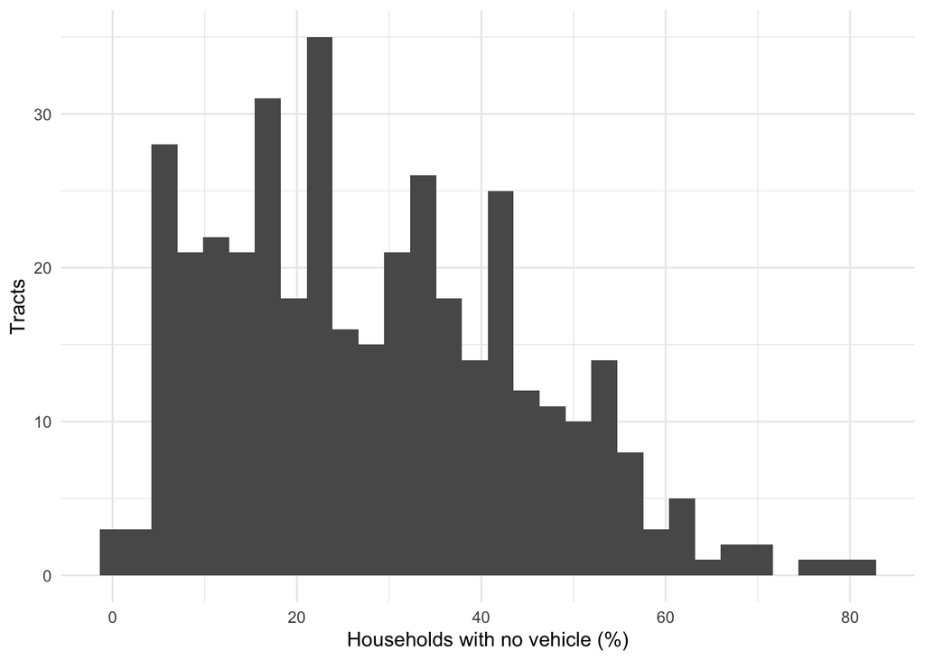

```r
ggplot(philly_tracts %>% filter(!is.na(y)), aes(x = y)) +
  geom_histogram(bins = 30) +
  labs(x = "Households with no vehicle (%)", y = "Tracts") +
  theme_minimal()
```

Because the coefficient of variation divides by the estimate itself, low car-free shares look unreliable even when the margin of error is modest in percentage-point terms. We check whether the low-reliability tracts are simply the low-share tracts.

```r
philly_tracts %>%
  st_drop_geometry() %>%
  filter(!is.na(y)) %>%
  mutate(reliability = case_when(
    y_cv < 12  ~ "High",
    y_cv <= 40 ~ "Moderate",
    TRUE       ~ "Low"
  )) %>%
  group_by(reliability) %>%
  summarise(n_tracts      = n(),
            median_share  = round(median(y), 1),
            median_moe_pp = round(median(y_moe), 1))
```

```
# A tibble: 3 × 4
  reliability n_tracts median_share median_moe_pp
  <chr>          <int>        <dbl>         <dbl>
1 High              29         54.3           8.2
2 Low               46          6             5.1
3 Moderate         313         27.9           9.7
```

**Answer:** The outcome is the share of households in each tract with no vehicle available. A transit agency or the City’s Office of Transportation would want to predict it because car-free households depend entirely on transit, walking and cycling to reach jobs, groceries and health care, so knowing where they are guides where service cuts would hurt most and where new bus routes or bike-share stations would do the most good. Reliability is acceptable. Of the 388 tracts with households, 29 are high, 313 moderate and 46 low, with a median CV of 23.4%; a further 20 tracts have no households, so no rate exists for them. As in Assignment 3, low reliability here says more about the size of the estimate than the size of the error. The 46 low-reliability tracts have a median car-free share of just 6.0%, yet their median margin of error is 5.1 percentage points, the *smallest* of the three groups (against 9.7 for moderate and 8.2 for high). A handful of tracts with no car-free households at all have an infinite CV for the same reason. Since only about 12% of tracts are low reliability, well under the one-third threshold, we proceed with this outcome.

### 1C: Decide which tracts to model

```r
tracts <- philly_tracts %>%
  filter(total_popE > 0,
         !is.na(y),
         !is.na(med_income),
         !is.na(pct_renter),
         !is.na(pct_ba),
         !is.na(med_age))

nrow(philly_tracts)
```

```
[1] 408
```

```r
nrow(tracts)
```

```
[1] 381
```

```r
philly_tracts %>%
  st_drop_geometry() %>%
  filter(!GEOID %in% tracts$GEOID) %>%
  mutate(tract = str_extract(NAME, "Tract [^;]+")) %>%
  select(tract, total_popE, hhE, med_income) %>%
  arrange(desc(hhE))
```

```
           tract total_popE  hhE med_income
1      Tract 301       6446 2642         NA
2      Tract 277       5489 2448         NA
3      Tract 205       3383 1663         NA
4      Tract 285       2625 1081         NA
5      Tract 165       2165  978         NA
6      Tract 148        892  525         NA
7     Tract 9802        396   13         NA
8  Tract 9809.02          0    0         NA
9     Tract 9808          0    0         NA
10  Tract 369.01         49    0         NA
11    Tract 9805          0    0         NA
12    Tract 9806          0    0         NA
13    Tract 9891       1240    0         NA
14    Tract 9893        160    0         NA
15 Tract 9800.01          0    0         NA
16 Tract 9800.02          0    0         NA
17 Tract 9809.06          0    0         NA
18    Tract 9892          0    0         NA
19 Tract 9809.01          0    0         NA
20 Tract 9800.03          0    0         NA
21 Tract 9807.01          0    0         NA
22 Tract 9809.03          0    0         NA
23 Tract 9809.05          0    0         NA
24    Tract 9804          0    0         NA
25 Tract 9807.02          0    0         NA
26    Tract 9803          0    0         NA
27 Tract 9809.04          0    0         NA
```

**Answer:** We lose 27 of 408 tracts, leaving 381. Twenty of them have no households at all, so the outcome is a division of zero by zero and is undefined rather than missing. As in Assignment 3, most of these belong to the 98xx series, which the Census Bureau uses for parks, the airport and other largely non-residential land. Three of them, tracts 9891, 9893 and 369.01, do have residents (1,240, 160 and 49 people) but no households, so everyone there lives in group quarters such as institutions or dormitories, which sit outside the household universe the outcome is built on.

The remaining seven are a different problem. Each has households but no published median income. One of them, tract 9802, has only 13 households and a median age of 75, which points to a care facility, and dropping it costs nothing. The other six (tracts 148, 165, 205, 277, 285 and 301) are ordinary residential tracts with between 525 and 2,642 households, and their missing income is a gap in the published data rather than an absence of people. We follow the template and exclude them, but this is a real cost: these are exactly the kind of tracts an agency would want a prediction for. Filling their income with the citywide median, flagged with a dummy, would be the obvious alternative and is worth testing in a later version.

## Part 2: Baseline model

### 2A: Look first

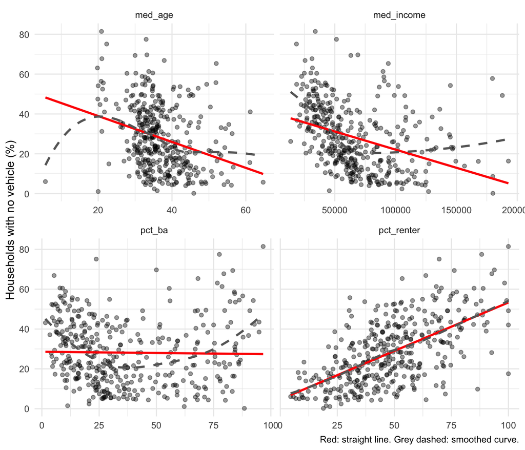

```r
tracts %>%
  st_drop_geometry() %>%
  select(y, med_income, pct_renter, pct_ba, med_age) %>%
  pivot_longer(-y, names_to = "predictor", values_to = "value") %>%
  ggplot(aes(x = value, y = y)) +
  geom_point(alpha = 0.4) +
  geom_smooth(method = "lm", se = FALSE, colour = "red") +
  geom_smooth(method = "loess", se = FALSE, colour = "grey40", linetype = "dashed") +
  facet_wrap(~ predictor, scales = "free_x") +
  labs(x = NULL, y = "Households with no vehicle (%)",
       caption = "Red: straight line. Grey dashed: smoothed curve.") +
  theme_minimal()
```

The red line is what a linear model can see; the grey curve is what the data actually do. Where the two diverge, a transformation in Part 5 may help. Three things stand out. Income bends sharply: the car-free share falls steeply up to a median income of roughly $75,000 and is flat, or even rising slightly, above $100,000, which already suggests a log. Education is U-shaped: car-free shares are high in tracts with few graduates, lowest around 30%, and high again where most adults hold a degree. This is the two car-free populations from Part 1 showing up in the data, and it explains why the straight red line for education is nearly flat. Renter share, by contrast, is close to linear, and the red and grey lines almost coincide.

### 2B: Fit and log

```r
f1 <- y ~ med_income + pct_renter + pct_ba + med_age

m1 <- lm(f1, data = tracts)
summary(m1)
```

```
Call:
lm(formula = f1, data = tracts)

Residuals:
    Min      1Q  Median      3Q     Max
-34.703  -8.376  -1.087   8.183  46.378

Coefficients:
              Estimate Std. Error t value Pr(>|t|)
(Intercept)  2.414e+01  4.828e+00   5.000 8.83e-07 ***
med_income  -1.783e-04  3.812e-05  -4.676 4.08e-06 ***
pct_renter   3.675e-01  4.336e-02   8.475 5.40e-16 ***
pct_ba       9.983e-02  5.004e-02   1.995   0.0468 *
med_age     -1.496e-01  9.111e-02  -1.642   0.1013
---
Signif. codes:  0 '***' 0.001 '**' 0.01 '*' 0.05 '.' 0.1 ' ' 1

Residual standard error: 12.34 on 376 degrees of freedom
Multiple R-squared:  0.4321,    Adjusted R-squared:  0.426
F-statistic: 71.51 on 4 and 376 DF,  p-value: < 2.2e-16
```

```r
model_log <- model_log %>%
  add_row(model = "m1", added = "ACS baseline",
          cv_rmse = cv_rmse(f1, tracts),
          notes = "income, renter share, BA+ share, median age")

model_log
```

```
# A tibble: 1 × 4
  model added        cv_rmse notes
  <chr> <chr>          <dbl> <chr>
1 m1    ACS baseline    12.4 income, renter share, BA+ share, median age
```

On tracts it hasn’t seen, the baseline model misses by about **12.4 percentage points** of households with no vehicle. With most tracts’ car-free share somewhere between about 10% and 40%, that is a substantial error: the model can place a tract in the right half of the distribution, but not much more. Its in-sample R² of 0.43 tells the same story.

### 2C: Where is the baseline wrong?

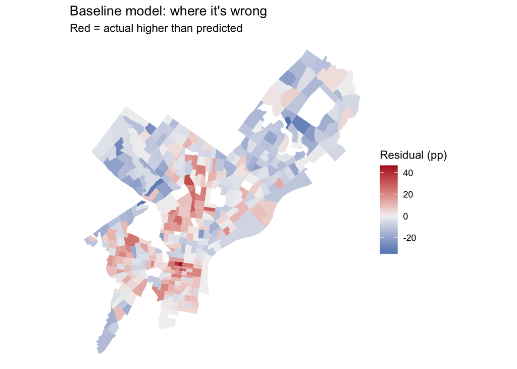

```r
tracts <- tracts %>% mutate(resid_m1 = residuals(m1))

ggplot(tracts) +
  geom_sf(aes(fill = resid_m1), color = NA) +
  scale_fill_gradient2(low = "#2166ac", mid = "grey95", high = "#b2182b", midpoint = 0) +
  theme_void() +
  labs(title = "Baseline model: where it's wrong",
       subtitle = "Red = actual higher than predicted",
       fill = "Residual (pp)")
```

**Answer:** The residuals are not scattered randomly. The model under-predicts (red) in a continuous band around the centre: Center City and the rowhouse blocks of South Philadelphia, where the single largest miss sits, North Philadelphia, and much of West Philadelphia. In these places more households go without a car than their income and tenure alone would suggest. It over-predicts (blue) almost everywhere in the Northeast and Northwest, and along the far Southwest, where households of similar income still own cars. What these places have in common is something the ACS baseline cannot see: **how easy it is to live without a car**. Density, closeness to the centre, and the availability of alternatives such as bike share all make car ownership less necessary, while the outer neighbourhoods are built around driving. Part 3 therefore pulls layers that capture the presence of cars on the street and access to alternatives.

## Part 3: Getting data from Philadelphia’s open data portal

```r
# Encode every special character (including the % in LIKE patterns), and retry
# a few times, because the Carto server occasionally drops a connection.
carto_url <- function(sql, format) {
  paste0("https://phl.carto.com/api/v2/sql?format=", format,
         "&q=", URLencode(sql, reserved = TRUE))
}

with_retry <- function(f, tries = 3) {
  for (i in seq_len(tries)) {
    out <- tryCatch(f(), error = function(e) e)
    if (!inherits(out, "error")) return(out)
    message("Carto request failed (attempt ", i, "): ", conditionMessage(out))
    Sys.sleep(3 * i)
  }
  stop(out)
}

carto_get <- function(sql) with_retry(function() st_read(carto_url(sql, "GeoJSON"), quiet = TRUE))
carto_csv <- function(sql) with_retry(function() read_csv(carto_url(sql, "csv"), show_col_types = FALSE))
```

Before filtering on offense types and 311 service names, we check the exact labels the tables use.

```r
carto_csv("SELECT text_general_code, COUNT(*) AS n
           FROM incidents_part1_part2
           WHERE dispatch_date >= '2023-01-01' AND dispatch_date < '2024-01-01'
           GROUP BY text_general_code ORDER BY n DESC")
```

```
# A tibble: 32 × 2
   text_general_code                 n
   <chr>                         <dbl>
 1 Thefts                        37054
 2 Other Assaults                25986
 3 Motor Vehicle Theft           22478
 4 Vandalism/Criminal Mischief   17346
 5 All Other Offenses            13334
 6 Theft from Vehicle            13002
 7 Fraud                          7661
 8 Aggravated Assault No Firearm  5134
 9 Burglary Residential           3800
10 Aggravated Assault Firearm     3320
# ℹ 22 more rows
```

```r
carto_csv("SELECT service_name, COUNT(*) AS n
           FROM public_cases_fc
           WHERE requested_datetime >= '2023-01-01' AND requested_datetime < '2024-01-01'
             AND service_name ILIKE '%vehicle%'
           GROUP BY service_name ORDER BY n DESC")
```

```
# A tibble: 1 × 2
  service_name          n
  <chr>             <dbl>
1 Abandoned Vehicle 31131
```

### Our layers

We pull three layers, all from 2023 so they sit inside the ACS window. Each is an indirect measure of **how many cars are on a tract’s streets**, which is the thing the baseline cannot see.

```r
# 1. Motor vehicle thefts, 2023
veh_theft <- carto_get(
  "SELECT the_geom, text_general_code, dispatch_date
   FROM incidents_part1_part2
   WHERE dispatch_date >= '2023-01-01' AND dispatch_date < '2024-01-01'
     AND text_general_code = 'Motor Vehicle Theft'"
) %>%
  st_transform(st_crs(tracts))

# 2. Thefts from vehicles, 2023
theft_from_veh <- carto_get(
  "SELECT the_geom, text_general_code, dispatch_date
   FROM incidents_part1_part2
   WHERE dispatch_date >= '2023-01-01' AND dispatch_date < '2024-01-01'
     AND text_general_code = 'Theft from Vehicle'"
) %>%
  st_transform(st_crs(tracts))

# 3. 311 abandoned vehicle requests, 2023
abandoned <- carto_get(
  "SELECT the_geom, service_name, requested_datetime
   FROM public_cases_fc
   WHERE requested_datetime >= '2023-01-01' AND requested_datetime < '2024-01-01'
     AND service_name = 'Abandoned Vehicle'"
) %>%
  st_transform(st_crs(tracts))

# 4. Indego stations (Week 4 feed)
stations <- st_read("https://www.rideindego.com/stations/json/", quiet = TRUE) %>%
  st_transform(st_crs(tracts))
```

Some records come back without a location. We drop them and count the loss, since every dropped point is an event that will not be counted in any tract.

```r
layers <- list(veh_theft = veh_theft, theft_from_veh = theft_from_veh,
               abandoned = abandoned, stations = stations)

tibble(layer   = names(layers),
       pulled  = map_int(layers, nrow),
       no_geom = map_int(layers, ~ sum(st_is_empty(.x))))
```

```
# A tibble: 4 × 3
  layer          pulled no_geom
  <chr>           <int>   <int>
1 veh_theft       22478     910
2 theft_from_veh  13002     943
3 abandoned       31131      56
4 stations          322       0
```

```r
veh_theft      <- veh_theft      %>% filter(!st_is_empty(.))
theft_from_veh <- theft_from_veh %>% filter(!st_is_empty(.))
abandoned      <- abandoned      %>% filter(!st_is_empty(.))
stations       <- stations       %>% filter(!st_is_empty(.))
```

**Answer:** The baseline knows who lives in a tract but not what the streets look like. A car that does not exist cannot be stolen, broken into or abandoned, so vehicle-related crime and 311 complaints work as indirect counts of the cars present in a place, information the ACS predictors only capture through income. We expect motor vehicle theft and thefts from vehicles to be higher where more cars are parked on the street, and abandoned-vehicle complaints to mark neighbourhoods where car ownership is common enough that disused cars accumulate. Indego stations capture the opposite side: the availability of an alternative to driving.

Two caveats are worth stating up front. First, vehicle crime also reflects where people *drive to*, not only where they live: Center City has many thefts from vehicles because commuters and visitors park there, which may weaken the link to residents’ car ownership. Second, 2023 motor vehicle thefts were inflated by the Kia and Hyundai theft wave, which targeted particular models rather than places with more cars. Finally, the Indego feed returns today’s stations rather than the 2023 network, so it uses a little information from the future (Rule 2). Any stations opened since 2023 make this feature slightly optimistic; a historical station list would be the clean fix.

## Part 4: Building spatial features

We build the features once, then add them to the model one at a time so each row of the log isolates one change.

```r
tract_pts <- st_point_on_surface(tracts)

city_hall <- st_sfc(st_point(c(-75.1636, 39.9526)), crs = 4326) %>%
  st_transform(st_crs(tracts))

nearest_idx <- st_nearest_feature(tract_pts, stations)

tracts <- tracts %>%
  mutate(
    area_sqmi = as.numeric(st_area(.)) / 27878400,

    # counts
    n_veh_theft      = lengths(st_intersects(., veh_theft)),
    n_theft_from_veh = lengths(st_intersects(., theft_from_veh)),
    n_abandoned      = lengths(st_intersects(., abandoned)),

    # densities
    veh_theft_per_1k_hh  = n_veh_theft / hhE * 1000,
    theft_from_veh_sqmi  = n_theft_from_veh / area_sqmi,
    abandoned_per_1k_hh  = n_abandoned / hhE * 1000,
    pop_per_sqmi         = total_popE / area_sqmi,

    # distances
    dist_station_mi = as.numeric(
      st_distance(tract_pts, stations[nearest_idx, ], by_element = TRUE)) / 5280,
    dist_ch_mi = as.numeric(st_distance(tract_pts, city_hall)) / 5280
  )

tracts %>%
  st_drop_geometry() %>%
  select(veh_theft_per_1k_hh, theft_from_veh_sqmi, abandoned_per_1k_hh,
         pop_per_sqmi, dist_station_mi, dist_ch_mi) %>%
  summary()
```

```
 veh_theft_per_1k_hh theft_from_veh_sqmi abandoned_per_1k_hh  pop_per_sqmi
 Min.   :  1.30      Min.   :  0.00      Min.   :  0.00      Min.   :  140
 1st Qu.: 18.84      1st Qu.: 63.35      1st Qu.: 26.38      1st Qu.:11803
 Median : 32.33      Median :108.14      Median : 45.70      Median :18626
 Mean   : 32.83      Mean   :135.03      Mean   : 47.58      Mean   :20498
 3rd Qu.: 42.98      3rd Qu.:171.25      3rd Qu.: 63.63      3rd Qu.:27834
 Max.   :166.67      Max.   :629.29      Max.   :413.25      Max.   :89887
 dist_station_mi      dist_ch_mi
 Min.   : 0.01124   Min.   : 0.1729
 1st Qu.: 0.15112   1st Qu.: 2.3091
 Median : 0.34205   Median : 4.3983
 Mean   : 1.74173   Mean   : 5.0474
 3rd Qu.: 2.26314   3rd Qu.: 7.1631
 Max.   :11.03056   Max.   :14.7878
```

Vehicle thefts and abandoned vehicles are normalised by **households**, since they are rough proxies for the number of household cars. Thefts from vehicles are normalised by **area**, because many of the victims’ cars belong to visitors rather than residents, so a per-household rate would be meaningless in commercial tracts. Because every count is filled with 0 where nothing was recorded, no row is lost (Rule 1).

As the Week 3 lesson on small denominators warns, per-household rates can explode in tracts with very few households. We check the extremes before trusting them.

```r
tracts %>%
  st_drop_geometry() %>%
  arrange(desc(veh_theft_per_1k_hh)) %>%
  select(NAME, hhE, n_veh_theft, veh_theft_per_1k_hh, n_abandoned, abandoned_per_1k_hh) %>%
  head(8)
```

```
                                                  NAME  hhE n_veh_theft
1 Census Tract 9801; Philadelphia County; Pennsylvania   66          11
2  Census Tract 143; Philadelphia County; Pennsylvania  987         103
3  Census Tract 156; Philadelphia County; Pennsylvania  641          65
4  Census Tract 382; Philadelphia County; Pennsylvania 1221         123
5  Census Tract 381; Philadelphia County; Pennsylvania  317          30
6  Census Tract 200; Philadelphia County; Pennsylvania  514          48
7  Census Tract 157; Philadelphia County; Pennsylvania 1375         117
8  Census Tract 163; Philadelphia County; Pennsylvania  899          75
  veh_theft_per_1k_hh n_abandoned abandoned_per_1k_hh
1           166.66667           8           121.21212
2           104.35664          59            59.77710
3           101.40406          86           134.16537
4           100.73710         125           102.37510
5            94.63722         131           413.24921
6            93.38521          35            68.09339
7            85.09091         118            85.81818
8            83.42603          94           104.56062
```

Only one tract is a genuine small-denominator problem: Census Tract 9801, where 11 thefts among 66 households produce the city’s highest rate of 167 per 1,000. The next seven tracts have between 317 and 1,375 households and 30 to 123 thefts each, so their high rates rest on real volume rather than tiny denominators. Even so, the distribution is long-tailed, which is a reason to expect the log in Part 5 to help.

### 4E: Adding features one at a time

Each model adds one feature to the one before.

```r
base <- c("med_income", "pct_renter", "pct_ba", "med_age")

steps <- list(
  m2 = list(add = "veh_theft_per_1k_hh", label = "vehicle thefts per 1k households (density)"),
  m3 = list(add = "theft_from_veh_sqmi", label = "thefts from vehicles per sq mi (density)"),
  m4 = list(add = "abandoned_per_1k_hh", label = "abandoned-vehicle 311 per 1k households (density)"),
  m5 = list(add = "dist_station_mi",     label = "distance to nearest Indego station (nearest)"),
  m6 = list(add = "dist_ch_mi",          label = "distance to City Hall (place)"),
  m7 = list(add = "pop_per_sqmi",        label = "population per sq mi (density)")
)

terms <- base
for (m in names(steps)) {
  terms <- c(terms, steps[[m]]$add)
  f <- reformulate(terms, response = "y")
  model_log <- model_log %>%
    add_row(model = m, added = steps[[m]]$label,
            cv_rmse = cv_rmse(f, tracts),
            notes = "cumulative")
}

model_log %>%
  mutate(change = cv_rmse - lag(cv_rmse))
```

```
# A tibble: 7 × 5
  model added                                             cv_rmse notes   change
  <chr> <chr>                                               <dbl> <chr>    <dbl>
1 m1    ACS baseline                                        12.4  inco… NA
2 m2    vehicle thefts per 1k households (density)          12.5  cumu…  0.0257
3 m3    thefts from vehicles per sq mi (density)            12.4  cumu… -0.0522
4 m4    abandoned-vehicle 311 per 1k households (density)   12.4  cumu…  0.00948
5 m5    distance to nearest Indego station (nearest)        11.3  cumu… -1.17
6 m6    distance to City Hall (place)                        9.78 cumu… -1.47
7 m7    population per sq mi (density)                       9.62 cumu… -0.164
```

Because features are added cumulatively, the order matters: a feature added late can look useless because an earlier one already carried its information. To check this, we also add each feature to the baseline **on its own**.

```r
alone <- map_dfr(steps, function(s) {
  tibble(feature = s$label,
         cv_rmse = cv_rmse(reformulate(c(base, s$add), response = "y"), tracts))
}) %>%
  mutate(vs_baseline = cv_rmse - model_log$cv_rmse[model_log$model == "m1"]) %>%
  arrange(cv_rmse)

alone
```

```
# A tibble: 6 × 3
  feature                                           cv_rmse vs_baseline
  <chr>                                               <dbl>       <dbl>
1 distance to City Hall (place)                        10.3     -2.17
2 distance to nearest Indego station (nearest)         11.3     -1.14
3 population per sq mi (density)                       11.4     -1.05
4 thefts from vehicles per sq mi (density)             12.4     -0.0419
5 abandoned-vehicle 311 per 1k households (density)    12.4     -0.0154
6 vehicle thefts per 1k households (density)           12.5      0.0257
```

**Answer:** Distance to City Hall helped most. Added to the baseline on its own, it lowered CV RMSE from 12.44 to 10.27 points, a cut of 2.17; added in sequence after the Indego feature, it still took off a further 1.47. This fits the baseline residual map: the largest misses followed distance from the centre, and distance from the centre is a summary of everything that makes going without a car practical, from jobs and shops within walking distance to the densest transit service.

The comparison between the two tables is itself instructive. On its own, distance to the nearest Indego station cut CV RMSE by 1.14 and population density by 1.05, but in sequence density added only 0.16. All three features largely measure the same thing, centrality. The Indego network is concentrated in and around Center City (the median tract is a third of a mile from a station, but the mean is 1.7 miles and the furthest tract is 11 miles away), so outside the core, distance to the nearest station is mostly distance to the centre under another name.

The disappointment was the vehicle-crime and 311 layers. Motor vehicle thefts made the model slightly *worse* (CV RMSE rose by 0.03 on its own), and thefts from vehicles and abandoned-vehicle complaints each improved it by less than 0.05 points. We expected a car that does not exist to be impossible to steal, but two things got in the way. First, thefts from vehicles follow where cars are *parked*, which in the centre means commuters’ and shoppers’ cars rather than residents’. Second, 2023 was the peak of the Kia and Hyundai theft wave, so motor vehicle thefts track where particular models were parked rather than how many cars there were. A small rise in CV RMSE is itself a finding: a predictor that carries no new information still costs the model a parameter, and cross-validation penalises that where in-sample R² would not.

## Part 5: Transforming features

Following the October 9 lecture, the outcome stays in percentage points so every row of the log is comparable; only predictors are transformed. We start from the full m7 specification and change one thing at a time.

### 5A: Logs

The Part 2A plots showed income bending, and the Part 4 summary showed density and the crime rates are heavily right-skewed: most tracts have modest values and a handful have very large ones.

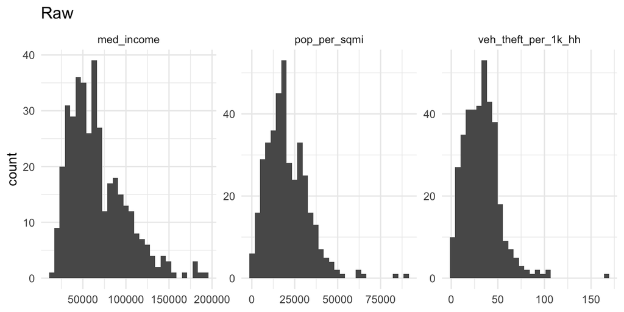

```r
tracts %>%
  st_drop_geometry() %>%
  select(med_income, pop_per_sqmi, veh_theft_per_1k_hh) %>%
  pivot_longer(everything()) %>%
  ggplot(aes(x = value)) + geom_histogram(bins = 30) +
  facet_wrap(~ name, scales = "free") + theme_minimal() +
  labs(title = "Raw", x = NULL)
```

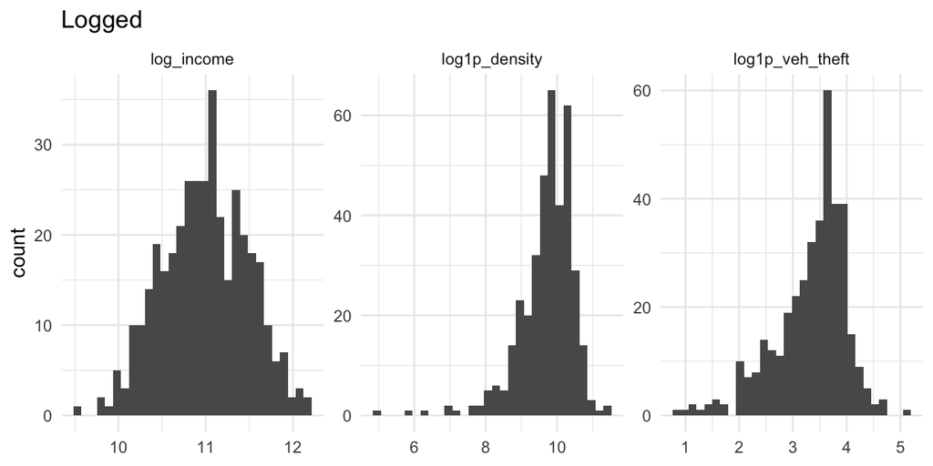

```r
tracts %>%
  st_drop_geometry() %>%
  transmute(log_income = log(med_income),
            log1p_density = log1p(pop_per_sqmi),
            log1p_veh_theft = log1p(veh_theft_per_1k_hh)) %>%
  pivot_longer(everything()) %>%
  ggplot(aes(x = value)) + geom_histogram(bins = 30) +
  facet_wrap(~ name, scales = "free") + theme_minimal() +
  labs(title = "Logged", x = NULL)
```

Income is always positive, so it takes a plain `log()`. The density and crime rates can be zero, so they take `log1p()`.

```r
spec7 <- c(base, map_chr(steps, "add"))

swap <- function(spec, old, new) c(setdiff(spec, old), new)

spec_log_inc <- swap(spec7, "med_income", "log(med_income)")
model_log <- model_log %>%
  add_row(model = "m8", added = "log of median income",
          cv_rmse = cv_rmse(reformulate(spec_log_inc, response = "y"), tracts),
          notes = "replaces linear income in m7")

spec_log_dens <- swap(spec_log_inc, "pop_per_sqmi", "log1p(pop_per_sqmi)")
model_log <- model_log %>%
  add_row(model = "m9", added = "log1p of population density",
          cv_rmse = cv_rmse(reformulate(spec_log_dens, response = "y"), tracts),
          notes = "builds on m8")

spec_log_crime <- spec_log_dens %>%
  swap("veh_theft_per_1k_hh", "log1p(veh_theft_per_1k_hh)") %>%
  swap("abandoned_per_1k_hh", "log1p(abandoned_per_1k_hh)") %>%
  swap("theft_from_veh_sqmi", "log1p(theft_from_veh_sqmi)")
model_log <- model_log %>%
  add_row(model = "m10", added = "log1p of the three vehicle-crime/311 rates",
          cv_rmse = cv_rmse(reformulate(spec_log_crime, response = "y"), tracts),
          notes = "builds on m9")

model_log %>% tail(4)
```

```
# A tibble: 4 × 4
  model added                                      cv_rmse notes
  <chr> <chr>                                        <dbl> <chr>
1 m7    population per sq mi (density)                9.62 cumulative
2 m8    log of median income                          9.22 replaces linear inco…
3 m9    log1p of population density                   9.44 builds on m8
4 m10   log1p of the three vehicle-crime/311 rates    9.14 builds on m9
```

### 5B: Squared term

Distance to City Hall is the obvious candidate for a curve: car-free shares should fall quickly as one leaves the core and then level off in the outer neighbourhoods, where nearly everyone drives.

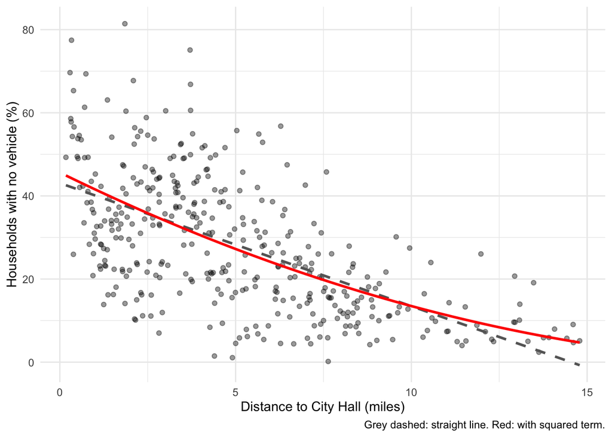

```r
ggplot(tracts, aes(x = dist_ch_mi, y = y)) +
  geom_point(alpha = 0.4) +
  geom_smooth(method = "lm", formula = y ~ x, se = FALSE, colour = "grey40", linetype = "dashed") +
  geom_smooth(method = "lm", formula = y ~ x + I(x^2), se = FALSE, colour = "red") +
  labs(x = "Distance to City Hall (miles)", y = "Households with no vehicle (%)",
       caption = "Grey dashed: straight line. Red: with squared term.") +
  theme_minimal()
```

```r
best_log <- spec_log_crime   # m10 had the lowest CV RMSE of the log models

spec_sq <- c(best_log, "I(dist_ch_mi^2)")
model_log <- model_log %>%
  add_row(model = "m11", added = "squared distance to City Hall",
          cv_rmse = cv_rmse(reformulate(spec_sq, response = "y"), tracts),
          notes = "linear + squared distance")
```

### 5C: Categorical variable

Instead of a smooth curve, we can treat distance as rings around the centre. Planners already talk about the city this way, and a ring does not assume the relationship has any particular shape.

```r
tracts <- tracts %>%
  mutate(
    ring = case_when(
      dist_ch_mi < 2 ~ "Core",
      dist_ch_mi < 5 ~ "Inner",
      TRUE           ~ "Outer"
    ),
    ring = factor(ring, levels = c("Core", "Inner", "Outer"))
  )

tracts %>% st_drop_geometry() %>% count(ring)
```

```
   ring   n
1  Core  79
2 Inner 134
3 Outer 168
```

```r
spec_ring <- c(setdiff(best_log, "dist_ch_mi"), "ring")
model_log <- model_log %>%
  add_row(model = "m12", added = "ring (Core / Inner / Outer) instead of distance",
          cv_rmse = cv_rmse(reformulate(spec_ring, response = "y"), tracts),
          notes = "reference level = Core")

m_ring <- lm(reformulate(spec_ring, response = "y"), data = tracts)
summary(m_ring)$coefficients[c("ringInner", "ringOuter"), ]
```

```
            Estimate Std. Error   t value     Pr(>|t|)
ringInner  -8.338543   1.808243 -4.611406 5.522275e-06
ringOuter -14.973595   2.024570 -7.395939 9.532217e-13
```

```r
model_log
```

```
# A tibble: 12 × 4
   model added                                             cv_rmse notes
   <chr> <chr>                                               <dbl> <chr>
 1 m1    ACS baseline                                        12.4  income, rent…
 2 m2    vehicle thefts per 1k households (density)          12.5  cumulative
 3 m3    thefts from vehicles per sq mi (density)            12.4  cumulative
 4 m4    abandoned-vehicle 311 per 1k households (density)   12.4  cumulative
 5 m5    distance to nearest Indego station (nearest)        11.3  cumulative
 6 m6    distance to City Hall (place)                        9.78 cumulative
 7 m7    population per sq mi (density)                       9.62 cumulative
 8 m8    log of median income                                 9.22 replaces lin…
 9 m9    log1p of population density                          9.44 builds on m8
10 m10   log1p of the three vehicle-crime/311 rates           9.14 builds on m9
11 m11   squared distance to City Hall                        9.00 linear + squ…
12 m12   ring (Core / Inner / Outer) instead of distance      9.31 reference le…
```

All three rings have well over 20 tracts, so every cross-validation fold will contain each category.

**Answer:** The log of median income helped most, lowering CV RMSE from 9.62 to 9.22 points. This matches the scatterplot in Part 2A: the car-free share falls steeply across the lowest incomes and then flattens, so a straight line was overstating the effect of income among better-off tracts and understating it among the poorest. A log says that going from $20,000 to $40,000 matters as much as going from $60,000 to $120,000, which is closer to how car ownership actually works.

Reading the categorical variable, with **Core** (within two miles of City Hall) as the reference level: holding income, tenure, education, age, density and the vehicle-crime features constant, a tract in the **Outer** ring is predicted to have about 15.0 percentage points fewer households without a car than an otherwise similar tract in the Core (and an **Inner** tract about 8.3 points fewer).